# Profiling code

Di Cook, Heike Hofmann  
3/7/2014

### Outline

- some more lab work: 10 min
- profiling nasa temperature trends
- more details on the projects

### Exercise 4: Temperature trends in NASA data

We have been discussing two blocks of code, block #1 and block #2, for computing temperature trends in the NASA data set. The goal of this week's lab is to profile the code in block #1 and make (small) changes to it to increase its execution speed. By small we mean that you should not change the code chunk completely (we already know that block #2 or #3 are faster), but identify the slow routines/statements in the block and try to replace these with faster alternatives. For your report, keep track of the ideas you had (together with a motivation of what gave you the idea) and the execution times, even if the idea did not lead to a speed-up. This will give us a list of things that worked and that did not work.

Aim for a final speed-up of at least 30% based on the original runtime of block #1

Spend 10 minutes on trying to answer this question.

### Block #1

baseline to beat:

```
   user  system elapsed
 12.478   0.447  12.923
```

```r
# Block #1
library(profr)
profr.res <- profr({
  nasa.trend<-unique(nasa[,c("x","y")])
  nasa.trend$temperature <- 0
  ny<-length(unique(nasa$y))
  for (i in unique(nasa$x)) {
    for (j in unique(nasa$y)) {
      x <- subset(nasa, x==i&y==j)
      nasa.trend$temperature[(i-1)*ny+j] <- coefficients(rlm(temperature~year+month, data=x))[2]
      }
    }
  })
```

### Identifying slow expressions/functions

- first 15 levels are due to Rpres - ignore it
- bridging at higher levels??? - ignore it
- what is slow? - subsetting

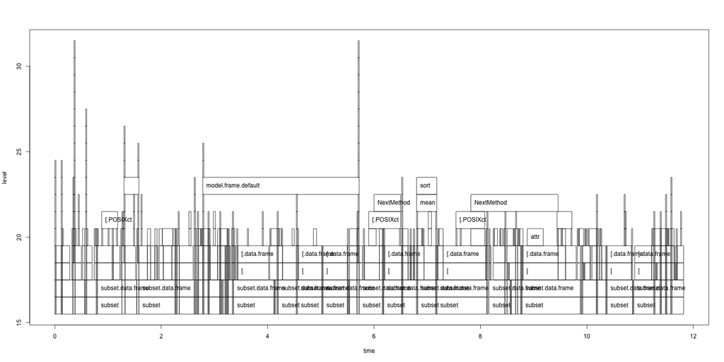

### Understanding profr output

- at each time point (every 0.02 seconds), a snapshot of the stack is taken (using the command `Rprof`)
- profr is a wrapper around that output, that tries to associate start and end time to the commands
- 'bridging' is therefore impossible (a function can't exist in the stack if its surrounding function doesn't exist anymore)

```r
library(dplyr)
subset(profr.res,  (start <= 0.10) & level>=16) %.% arrange(start, level)
```

```
                       f level time start  end  leaf source
1                 unique    16 0.12  0.00 0.12 FALSE   base
2        lazyLoadDBfetch    17 0.08  0.00 0.08  TRUE   base
3      unique.data.frame    17 0.02  0.08 0.10 FALSE   base
4                      [    18 0.02  0.08 0.10 FALSE   base
5           [.data.frame    19 0.02  0.08 0.10 FALSE   base
6             duplicated    20 0.02  0.08 0.10 FALSE   base
7  duplicated.data.frame    21 0.02  0.08 0.10 FALSE   base
8             duplicated    22 0.02  0.08 0.10 FALSE   base
9                do.call    23 0.02  0.08 0.10 FALSE   base
10                 paste    24 0.02  0.08 0.10  TRUE   base
11        unique.default    17 0.02  0.10 0.12  TRUE   base
```

### Idea #1 Alternative to subsets

use indices instead of subsets:

```r
ptm <- proc.time()
  nasa.trend<-unique(nasa[,c("x","y")])
  nasa.trend$temperature <- 0
  ny<-length(unique(nasa$y))
  for (i in unique(nasa$x)) {
    for (j in unique(nasa$y)) {
      idx <- which(nasa$x==i & nasa$y==j)
      nasa.trend$temperature[(i-1)*ny+j] <- coefficients(rlm(temperature~year+month, data=nasa[idx,]))[2]
      }
    }
(pt2 <- proc.time() - ptm)
```

```
   user  system elapsed
  2.940   0.201   3.141
```

### `which` is better than `subset`

- huge savings (about four times faster) when using `which` instead of `subset`

```r
pt1
```

```
   user  system elapsed
 12.478   0.447  12.923
```

```r
pt2
```

```
   user  system elapsed
  2.940   0.201   3.141
```

- generally: any data frame operation is fairly slow

### Idea #2: eliminate double for loop

```r
ptm <- proc.time()
  nasa.trend<-unique(nasa[,c("x","y", "id")])
  nasa.trend$temperature <- 0
  for (i in 1:nrow(nasa.trend)) {
    idx <- which(nasa$id==nasa.trend$id[i])
    nasa.trend$temperature[i] <- coefficients(rlm(temperature~year+month, data=nasa[idx,]))[2]
  }
(pt3 <- proc.time() - ptm)
```

```
   user  system elapsed
  2.921   0.108   3.029
```

doesn't seem to make a difference

### Idea #3: exploit sorting of dataset

```r
ptm <- proc.time()
  nasa.trend<-unique(nasa[,c("y","x")])
  nasa.trend$temperature <- 0
  ny<-length(unique(nasa$y))
  nx<-length(unique(nasa$x))
  for (j in 1:unique(nasa$y)) {
    for (i in 1:unique(nasa$x)) {
    nasa.trend$temperature[(j-1)*ny+i] <- coefficients(rlm(temperature~year+month, data=nasa[(0:71)*nx*ny + (nx*(j-1)) +i,]))[2]
    }
  }
(pt4 <- proc.time() - ptm)
```

```
   user  system elapsed
  0.161   0.009   0.169
```

- very fast!
- **breaks easily!** doesn't work when the order of nasa data is changed ahead of time
- indexing is also very fiddly … why does it work?

### Are you set up for programming?

Run the following code to see:

```
library(devtools)
has_devel()
```

We will be dealing with setting up an R package on Wednesday in the lab …